# MPDW P5

Farrel Gilbran

2023-09-26

```r
# Memanggil Library
library("ggplot2")
library("tsibble")
library("tseries")
library("MASS")
library("ggplot2")
library("readxl")
```

```r
# Membaca Data Excel
data <- read_excel("Bitcoin Highest Stock Market Price 2022-2023 xlsx.xlsx")

# Mengonversi kolom 'Date' menjadi tipe data Date jika belum
data$Date <- as.Date(data$Date)

# Memfilter data hanya untuk rentang 1 Juli 2022 hingga 1 Juli 2023
data <- subset(data, Date >= as.Date("2022-07-01") & Date <= as.Date("2023-06-30"))

#Cek data
str(data)
```

```
## tibble [365 × 2] (S3: tbl_df/tbl/data.frame)
##  $ Date: Date[1:365], format: "2022-07-01" "2022-07-02" ...
##  $ High: num [1:365] 20633 19372 19558 20259 20635 ...
```

```r
#Data time series total
data.ts <- ts(data$High)
summary(data.ts)
```

```
##    Min. 1st Qu.  Median    Mean 3rd Qu.    Max.
##   16253   19636   22584   22921   26985   31390
```

```r
# Mengecek missing value
sum(is.na(data))
```

```
## [1] 0
```

```r
#Membagi data part 1 dan part 2
data1<-data.ts[1:310]
data2 <-data.ts[1:150]
```

#Data total (1-365) ##Eksplorasi plot data total

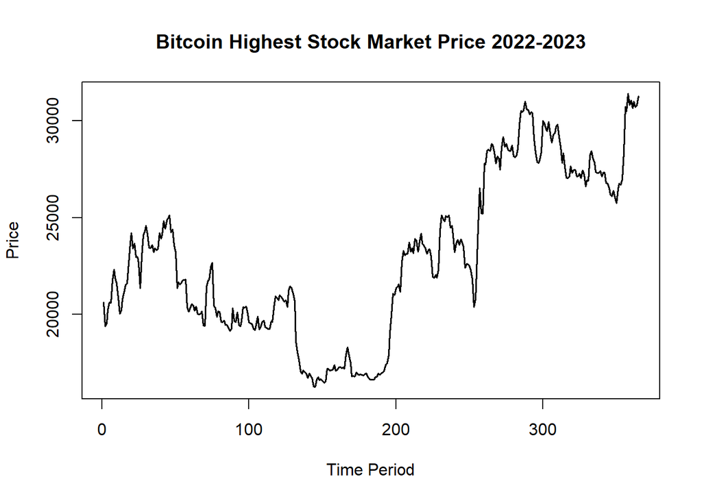

```r
#Eksplorasi plot data total
ts.plot(data.ts, main = "Bitcoin Highest Stock Market Price 2022-2023", ylab = "Price",xlab="Time Period" , lwd = 1.5)
```

### Plot ACF

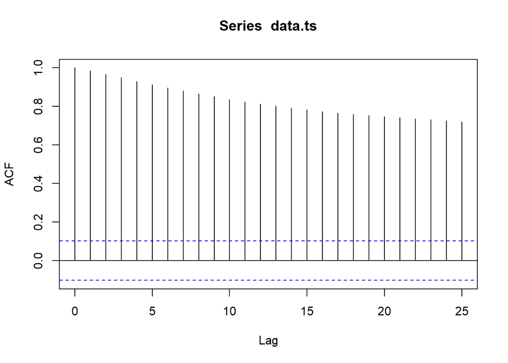

```r
acf(data.ts)
```

Berdasarkan plot ACF, terlihat bahwa plot ACF pada data tersebut *tails off*

### Uji ADF

```r
tseries::adf.test(data.ts)
```

```
##
##  Augmented Dickey-Fuller Test
##
## data:  data.ts
## Dickey-Fuller = -1.8325, Lag order = 7, p-value = 0.6476
## alternative hypothesis: stationary
```

$H_0$ : Data tidak stasioner dalam rataan

$H_1$ : Data stasioner dalam rataan

Berdasarkan uji ADF tersebut, didapat *p-value* sebesar 0.6476 yang lebih besar dari taraf nyata 5% sehingga tak tolak $H_0$ dan menandakan bahwa data tidak stasioner dalam rataan. Hal ini sesuai dengan hasil eksplorasi menggunakan plot time series dan plot ACF.

### Plot Box-Cox

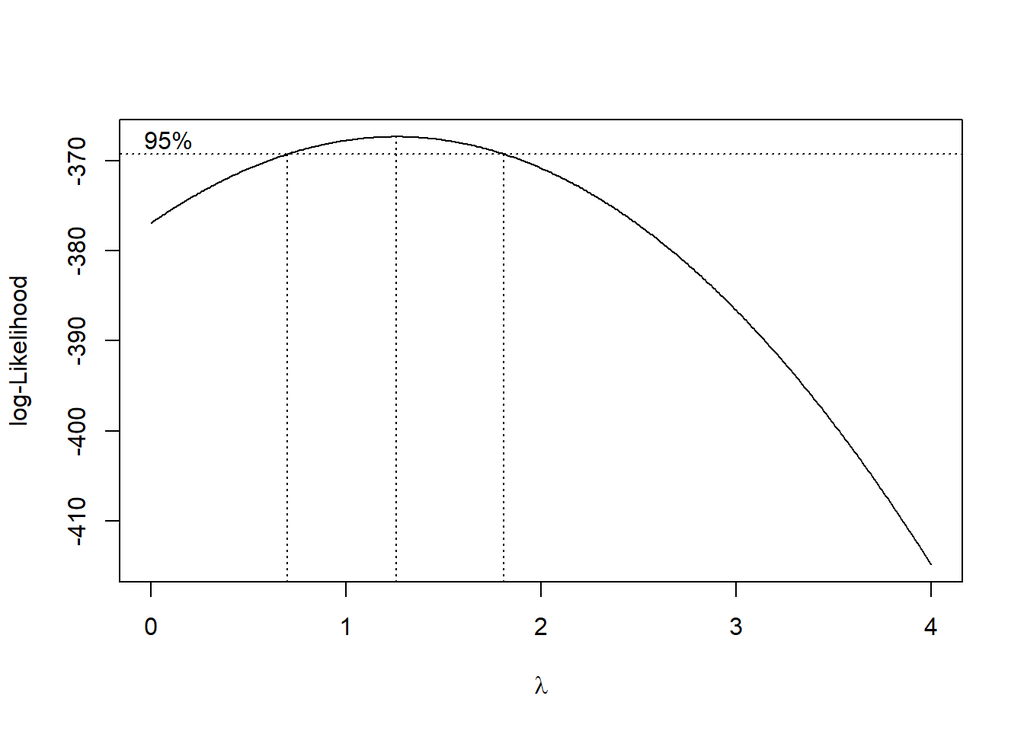

```r
index <- seq(1:365)
bc = boxcox(data.ts~index, lambda = seq(0,4,by=0.01))
```

```r
#Nilai Rounded Lambda
lambda <- bc$x[which.max(bc$y)]
lambda
```

```
## [1] 1.26
```

```r
#SK
bc$x[bc$y > max(bc$y) - 1/2 * qchisq(.95,1)]
```

```
##   [1] 0.70 0.71 0.72 0.73 0.74 0.75 0.76 0.77 0.78 0.79 0.80 0.81 0.82 0.83 0.84
##  [16] 0.85 0.86 0.87 0.88 0.89 0.90 0.91 0.92 0.93 0.94 0.95 0.96 0.97 0.98 0.99
##  [31] 1.00 1.01 1.02 1.03 1.04 1.05 1.06 1.07 1.08 1.09 1.10 1.11 1.12 1.13 1.14
##  [46] 1.15 1.16 1.17 1.18 1.19 1.20 1.21 1.22 1.23 1.24 1.25 1.26 1.27 1.28 1.29
##  [61] 1.30 1.31 1.32 1.33 1.34 1.35 1.36 1.37 1.38 1.39 1.40 1.41 1.42 1.43 1.44
##  [76] 1.45 1.46 1.47 1.48 1.49 1.50 1.51 1.52 1.53 1.54 1.55 1.56 1.57 1.58 1.59
##  [91] 1.60 1.61 1.62 1.63 1.64 1.65 1.66 1.67 1.68 1.69 1.70 1.71 1.72 1.73 1.74
## [106] 1.75 1.76 1.77 1.78 1.79 1.80
```

Gambar di atas menunjukkan nilai *rounded value* ($\lambda$) optimum sebesar **1,26** dan pada selang kepercayaan 95% nilai memiliki batas bawah **0,70** dan batas atas **1,80**. Selang tersebut memuat nilai satu sehingga dapat dikatakan bahwa data stasioner dalam ragam.

#Data Part 1 (1-310) ##Eksplorasi plot data part 1

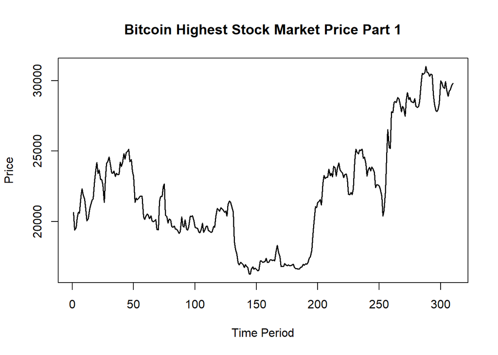

```r
ts.plot(data1, main = "Bitcoin Highest Stock Market Price Part 1", ylab = "Price",xlab="Time Period" , lwd = 1.5)
```

### Plot ACF

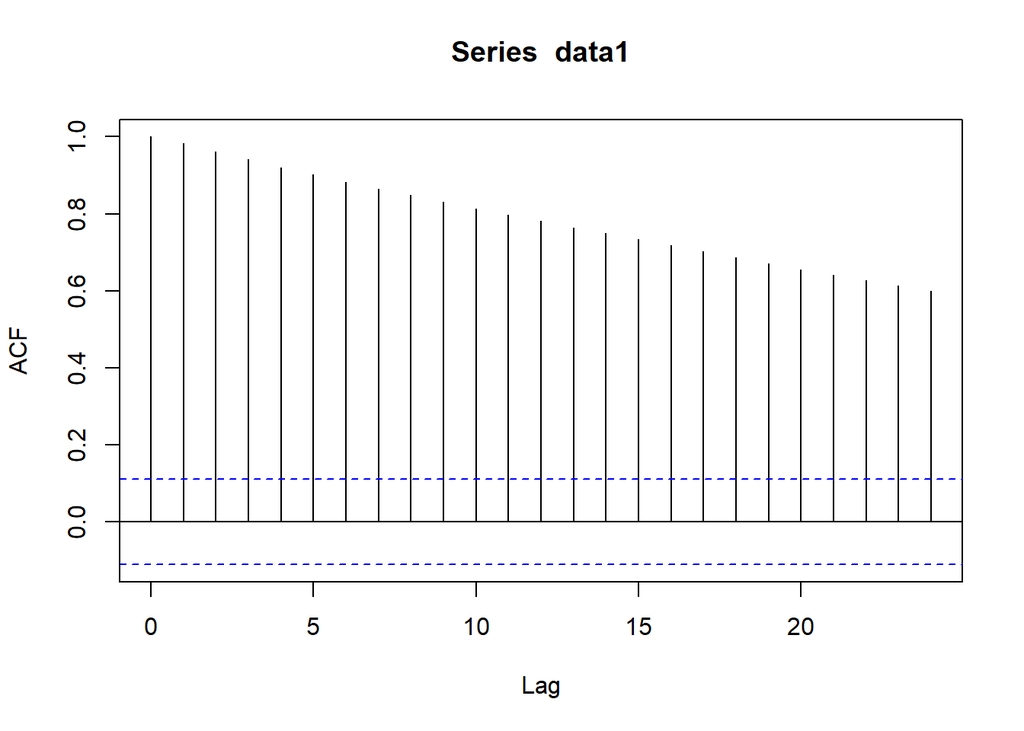

```r
acf(data1)
```

Berdasarkan plot ACF, terlihat bahwa plot ACF pada data tersebut cenderung *tails off*

### Uji ADF

```r
tseries::adf.test(data1)
```

```
##
##  Augmented Dickey-Fuller Test
##
## data:  data1
## Dickey-Fuller = -1.3837, Lag order = 6, p-value = 0.8362
## alternative hypothesis: stationary
```

$H_0$ : Data tidak stasioner dalam rataan

$H_1$ : Data stasioner dalam rataan

Berdasarkan uji ADF tersebut, didapat *p-value* sebesar 0.8362 yang lebih besar dari taraf nyata 5% sehingga tak tolak $H_0$ dan menandakan bahwa data tidak stasioner dalam rataan. Hal ini sesuai dengan hasil eksplorasi menggunakan plot time series dan plot ACF.

### Plot Box-Cox

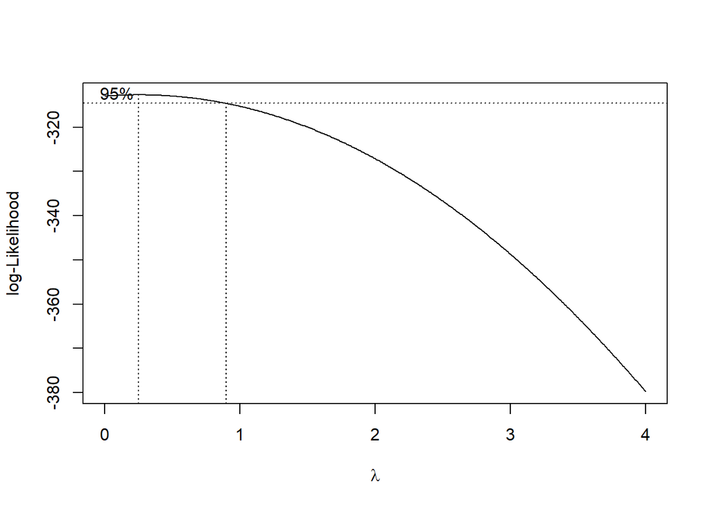

```r
index <- seq(1:310)
bc = boxcox(data1~index, lambda = seq(0,4,by=0.01))
```

```r
#Nilai Rounded Lambda
lambda <- bc$x[which.max(bc$y)]
lambda
```

```
## [1] 0.25
```

```r
#SK
bc$x[bc$y > max(bc$y) - 1/2 * qchisq(.95,1)]
```

```
##  [1] 0.00 0.01 0.02 0.03 0.04 0.05 0.06 0.07 0.08 0.09 0.10 0.11 0.12 0.13 0.14
## [16] 0.15 0.16 0.17 0.18 0.19 0.20 0.21 0.22 0.23 0.24 0.25 0.26 0.27 0.28 0.29
## [31] 0.30 0.31 0.32 0.33 0.34 0.35 0.36 0.37 0.38 0.39 0.40 0.41 0.42 0.43 0.44
## [46] 0.45 0.46 0.47 0.48 0.49 0.50 0.51 0.52 0.53 0.54 0.55 0.56 0.57 0.58 0.59
## [61] 0.60 0.61 0.62 0.63 0.64 0.65 0.66 0.67 0.68 0.69 0.70 0.71 0.72 0.73 0.74
## [76] 0.75 0.76 0.77 0.78 0.79 0.80 0.81 0.82 0.83 0.84 0.85 0.86 0.87 0.88 0.89
```

#Data Part 2 (1-150) ##Eksplorasi plot data part 2

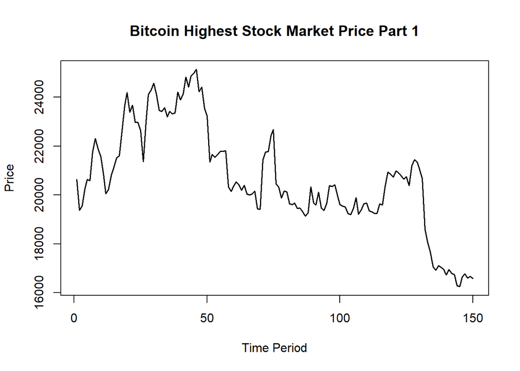

```r
ts.plot(data2, main = "Bitcoin Highest Stock Market Price Part 1", ylab = "Price",xlab="Time Period" , lwd = 1.5)
```

### Plot ACF

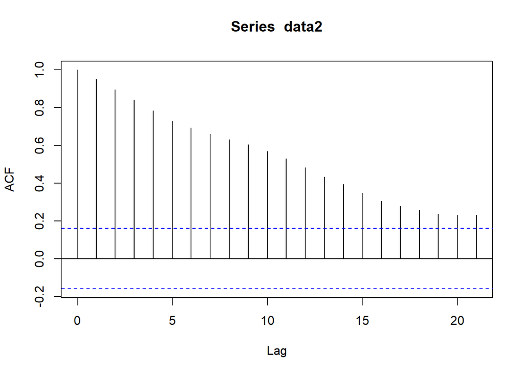

```r
acf(data2)
```

Berdasarkan plot ACF, terlihat bahwa plot ACF pada data tersebut cenderung *tails off*

### Uji ADF

```r
tseries::adf.test(data2)
```

```
##
##  Augmented Dickey-Fuller Test
##
## data:  data2
## Dickey-Fuller = -2.6008, Lag order = 5, p-value = 0.3261
## alternative hypothesis: stationary
```

$H_0$ : Data tidak stasioner dalam rataan

$H_1$ : Data stasioner dalam rataan

Berdasarkan uji ADF tersebut, didapat *p-value* sebesar 0.3261 yang lebih besar dari taraf nyata 5% sehingga tak tolak $H_0$ dan menandakan bahwa data tidak stasioner dalam rataan. Hal ini sesuai dengan hasil eksplorasi menggunakan plot time series dan plot ACF.

### Plot Box-Cox

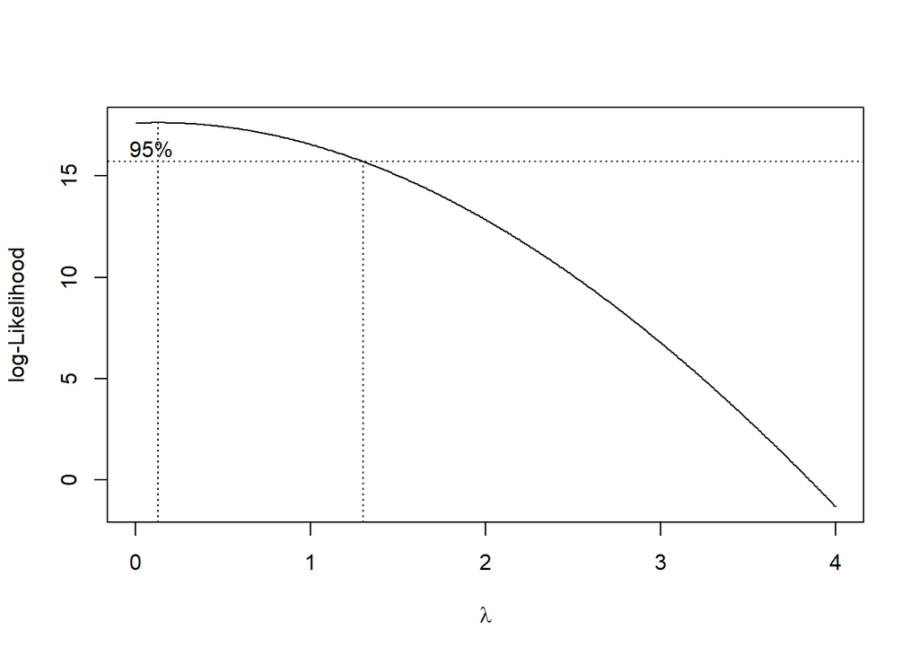

```r
index <- seq(1:150)
bc = boxcox(data2~index, lambda = seq(0,4,by=0.01))
```

```r
#Nilai Rounded Lambda
lambda <- bc$x[which.max(bc$y)]
lambda
```

```
## [1] 0.13
```

```r
#SK
bc$x[bc$y > max(bc$y) - 1/2 * qchisq(.95,1)]
```

```
##   [1] 0.00 0.01 0.02 0.03 0.04 0.05 0.06 0.07 0.08 0.09 0.10 0.11 0.12 0.13 0.14
##  [16] 0.15 0.16 0.17 0.18 0.19 0.20 0.21 0.22 0.23 0.24 0.25 0.26 0.27 0.28 0.29
##  [31] 0.30 0.31 0.32 0.33 0.34 0.35 0.36 0.37 0.38 0.39 0.40 0.41 0.42 0.43 0.44
##  [46] 0.45 0.46 0.47 0.48 0.49 0.50 0.51 0.52 0.53 0.54 0.55 0.56 0.57 0.58 0.59
##  [61] 0.60 0.61 0.62 0.63 0.64 0.65 0.66 0.67 0.68 0.69 0.70 0.71 0.72 0.73 0.74
##  [76] 0.75 0.76 0.77 0.78 0.79 0.80 0.81 0.82 0.83 0.84 0.85 0.86 0.87 0.88 0.89
##  [91] 0.90 0.91 0.92 0.93 0.94 0.95 0.96 0.97 0.98 0.99 1.00 1.01 1.02 1.03 1.04
## [106] 1.05 1.06 1.07 1.08 1.09 1.10 1.11 1.12 1.13 1.14 1.15 1.16 1.17 1.18 1.19
## [121] 1.20 1.21 1.22 1.23 1.24 1.25 1.26 1.27 1.28 1.29 1.30
```

Gambar di atas menunjukkan nilai *rounded value* ($\lambda$) optimum sebesar **0,13** dan pada selang kepercayaan 95% nilai memiliki batas bawah **0,00** dan batas atas **1,30**. Selang tersebut memuat nilai satu sehingga dapat dikatakan bahwa data bangkitan stasioner dalam ragam.